# Mapping With more Data Presentation

Zixuan Liu, Zijie Huang

11/11/2020

# Introduction

- Objective: produce US county-level maps that shows declared hurricane.
- Source: https://www.fema.gov/openfema-data-page/public-assistance-funded-projects-details-v1.

## Clean Disaster Declaration Summaries Dataset

There are total 23 variables in FEMA dataset. For our aim of the project, we filtered down to include only the hurricanes and the dates of interest. The new dataset call DisasterSummariesCleaned. The head of five observations and importnat variables are listed below:

| femaDeclarationString | disasterNumber | incidentType | paProgramDeclared | designatedArea | year |
| --- | --- | --- | --- | --- | --- |
| DR-1866-AL | 1866 | Hurricane | 1 | Baldwin (County) | 2009 |
| DR-1866-AL | 1866 | Hurricane | 1 | Mobile (County) | 2009 |
| DR-1931-TX | 1931 | Hurricane | 1 | Dawson (County) | 2010 |
| DR-1931-TX | 1931 | Hurricane | 1 | Cottle (County) | 2010 |
| DR-1931-TX | 1931 | Hurricane | 1 | Garza (County) | 2010 |

## Clean Public Assistance Funded Projects Details Dataset

There are total 22 variables in FEMA dataset, we only interested in 11 of them. We made a new dataset call hurricaneClean. The head of five observations and selected variables are listed below:

| disasterNumber | year | damageCategory | county | state | projectAmount | federalShareObligated | totalObligated |
| --- | --- | --- | --- | --- | --- | --- | --- |
| 1866 | 2009 | Public Utilities | Mobile | Alabama | 0.00 | 0.00 | 0.00 |
| 1866 | 2009 | Public Utilities | Mobile | Alabama | 58425.34 | 43819.01 | 43819.01 |
| 1866 | 2009 | Public Utilities | Mobile | Alabama | 0.00 | 0.00 | 0.00 |
| 1866 | 2009 | Public Utilities | Mobile | Alabama | 12778.47 | 9583.85 | 9583.85 |
| 1866 | 2009 | Protective Measures | Mobile | Alabama | 15290.26 | 11467.70 | 11467.70 |

# Data Modification

- merged together with state and county mapping data from the “maps” R package
- The head of five observations and selected variables are listed below:

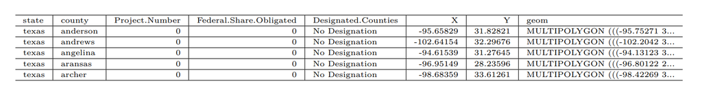

# Basic Mapping

- Map the data for each hurricane on separate state maps
- An example of state Texas can be previewed below.

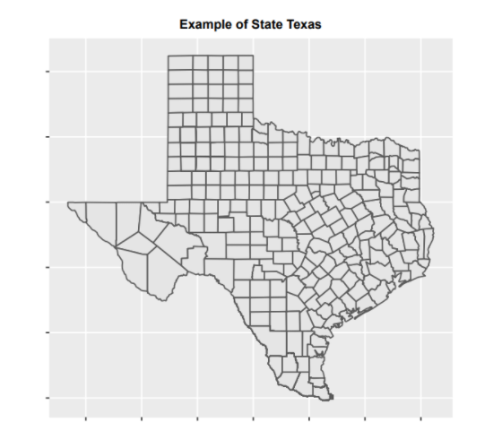

## Public Assistance Project Feature

An example of state Texas can be previewed below with Public Assistance Project Feature.

[figure not shown]

## Project Number Feature

An example of state Texas can be previewed below with Project Number Feature.

[figure not shown]

## Federal Share Obligated Feature

An example of state Texas can be previewed below with Federal Share Obligated Feature.

[figure not shown]

# Shiny App

A shiny application was created in order to further explore the maps.

[Click here to see the application](https://zhuangbc.shinyapps.io/FEMA_Project/)